# 1 Reproducible Analayses

## 1.1 Replication

> “There is increasing concern that in modern research, false findings may be the majority or even the vast majority of published research claims”

> – Ioannidis (2005)
- replication refers to re-running a previous experiment with as few differences as possible
  - aim: determine whether the original results were *robust* and are *replicable*
  - if yes, great! the original findings are reliable
  - if no, hmm, maybe the original findings were false positives? or due to some other factor?
- in recent years, researchers have tried to *replicate* classic studies in their field
  - but in many cases, they did not get the same effects the original study reported (and were famous for)
- this began the *replication crisis*

## 1.2 Reproducibility

- reproducibility refers to the ability to *reproduce* somebody’s analyses with their
  - data
  - *and* code
- it is not something we do once, nor is it something that will get us published
  - but it’s important for open science and encourages transparency

### 1.2.1 Replication vs. Reproducibility

- **replication** of a study
  - repeating an **experiment**
  - getting *similar* results
- **reproducibility** of analyses
  - repeating **analyses** of the *same data*
  - getting the *same* results
- e.g., when you submit a paper to a journal, they make ask for your data and code so reviewers can *reproduce* your analyses
  - requires data and code
- if you have interesting findings, other researchers (or future you) may want to *replicate* your study to see if they can *replicate* your findings
  - (may require) stimuli, set-up and presentation information, participant demographics

## 1.3 Open Science: Why should I care?

1. Science is cumulative
   - We should ensure we’re building on reliable, robust findings
   - i.e., it’s *good* scientific practice
2. Because the field cares
   - replication/reproducibility are beginning to be foregrounded by e.g., journals/job advertisements
3. Helps future you
   - pre-registration, reproducible analyses, clean and shareable data: all help *future you*

### 1.3.1 What can I do?

- there’s a variety of open science practices that we can choose to implement
- some suggestions from Kathawalla et al. (2021):

Level: Easy

1. Journal Club
2. Project workflow
3. Pre-prints

Level: Medium

4. Reproducible code
5. Sharing data
6. Transparent manuscripts
7. Pre-registration

Level: Difficult

8. Registered reports

### 1.3.2 How to do better science

- don’t be afraid of making mistakes
  - (most) researchers aren’t statisticians or programmers
  - do the best you can, and *be transparent*
- doing *some* of the steps is better than doing *none*

### 1.3.3 What will we learn here?

Design and Reporting

- Preregistration/Registered Reports
- Transparent writing

Analysis

- Reproducible code
  - with open source software (R, RStudio, packages)
  - dynamic reports with Quarto/Rmarkdown
- Project workflow
  - folder structure
    - how to sensibly set up your folders
  - contained environments
    - using RProjects and the `here` package

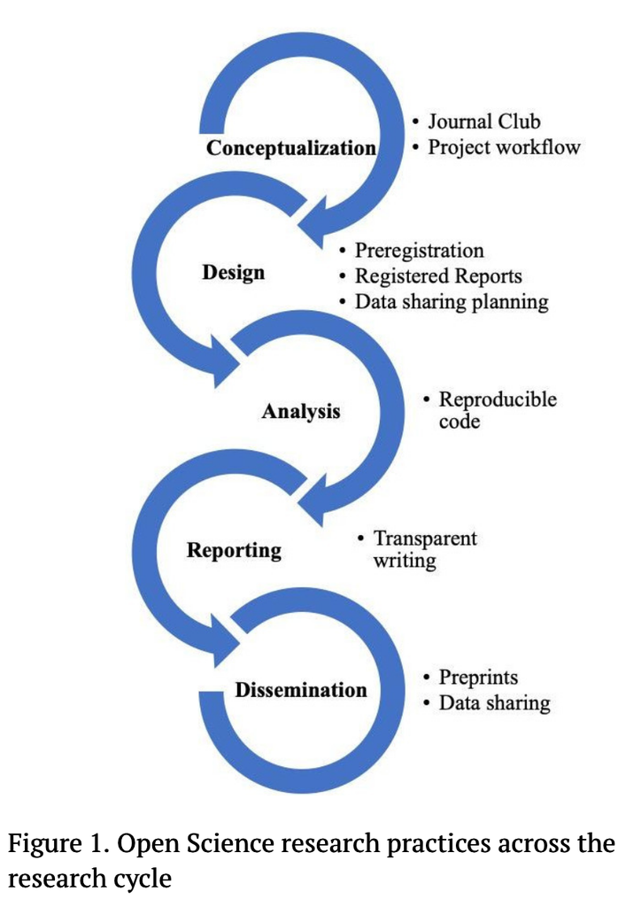

Image source: Kathawalla et al. (2021) (all rights reserved)

## 1.4 R is for Reproducibility

- we will be working with R, RStudio, Quarto, and RProjects
  - R: a programming language for statistical computing and graphics
  - RStudio: an integrated development environment (IDE)
    - RStudio Desktop
    - RStudio Server
  - Quarto (similar to Rmarkdown): dynamic reports
    - combining text, code, and printed tables and figures
  - RProjects: a workflow tool
    - contains all files necessary for a project
    - works with *relative* file paths

## 1.5 Exercises

### 1.5.1 RStudio

```r
# multiply 5 by 7
5*7
```

```
[1] 35
```

```r
# print some text
print("Hello World!")
```

```
[1] "Hello World!"
```

```r
# save an object 'number' with 5*7
number <- 5*7
```

```r
# save an object 'string' with text
string <- "Hello World!"
```

```r
# print number
number
```

```
[1] 35
```

```r
# print string
string
```

```
[1] "Hello World!"
```

```r
# do math with objects
number+number
```

```
[1] 70
```

```r
number*number
```

```
[1] 1225
```

```r
number*2
```

```
[1] 70
```

```r
month <- 5
```

```r
day <- 7
```

```r
month*day
```

```
[1] 35
```

### 1.5.2 Quarto[^2]

- R scripts are a great way to keep track of what you did
  - however, the output is not saved, and adding comments with `#` gets kind of chunky
  - enter: dynamic reports!
- dynamic reports are those that combine text, code, and output
  - they are a great tool for communicating, collaborating, and documenting
  - they are also fantastic for note-taking
- Rmarkdown vs. Quarto
  - both can combine text with code, outputting PDFs, Word Documents, html, or slides
  - main difference: Quarto has native support of a wider range of programming languages (e.g., Python and Julia)
- Want to know more? Check out [Hadley Wickham’s intro](https://r4ds.hadley.nz/quarto.html) (Wickham et al., n.d.)

#### 1.5.2.1 YAML

```r
---
title: "My title"
author: "My name"
format: html
---
```

- YAML is a human-readable programming language used to configure documents
- formatting is important: but be sandwiched between `---` and `---`
- in Quarto the output type must at least be given (with R: pdf, html, revealjs)

#### 1.5.2.2 Headings and text

```r
# This is a heading

This is text.

## This is a sub-heading

This is more text.
```

- headings are indicated by `#`
  - the number of `#`’s indicates the heading level

#### 1.5.2.3 Code snippets

```r
# do some math
year <- 1989
dog <- "Lola"
```

#### 1.5.2.4 In-line code

```r
I was born on `r month`/`r day`/`r year`. My dog's name is `r dog`.
```

I was born on 5/7/1989. My dog’s name is Lola.

- code output that was run *above* text can be called in-line using ``r` `

#### 1.5.2.5 Altogether

````markdown
---
title: "My title"
author: "My name"
format: html
---

# This is a heading

This is text.

## This is a sub-heading

This is more text.

Add some code chunks.

```{r}
# do some math
year <- 1989
dog <- "Lola"
```

And use call objects for in-line code: I was born on `r month`/`r day`/`r year`. My dog's name is `r dog`.
````

### 1.5.3 Quarto Exercises

3. Create a new Quarto document
   - File > New File > Quarto Document
   - Read the instructions
   - Practice running the chunks individually
   - render the document
   - verify that you can modify the code, re-run it, and see modified output
4. Create one new Quarto document for each of the three built-in formats: HTML, PDF and Word.
   - Render each of the three documents
   - How do the outputs differ?
   - How do the inputs differ?[^3]

### 1.5.4 Quarto cont’d

- Choose a Quarto document:
  - give it a title, your name (author), and unclick ‘Use visual markdown editor’
- Render
- YAML:

```r
title: "Eye-tracking during reading"
subtitle: "Lecture 2 notes"
author: "[YOUR NAME HERE]"
lang: en
date: `r Sys.Date()`
```

- Render
- you can now try writing your class notes in this document (if you’re brave)

# References

DeLong, K. A., Urbach, T. P., & Kutas, M. (2005). Probabilistic word pre-activation during language comprehension inferred from electrical brain activity. *Nature Neuroscience*, *8*(8), 1117–1121. https://doi.org/10.1038/nn1504

Ioannidis, J. P. A. (2005). Why most published research findings are false. *PLoS Med*, *2*(8), 2–8. https://doi.org/10.1371/journal.pmed.0020124

Kathawalla, U.-K., Silverstein, P., & Syed, M. (2021). Easing Into Open Science: A Guide for Graduate Students and Their Advisors. *Collabra: Psychology*, *7*(1), 18684. https://doi.org/10.1525/collabra.18684

Nieuwland, M. S., Politzer-Ahles, S., Heyselaar, E., Segaert, K., Darley, E., Kazanina, N., Von Grebmer Zu Wolfsthurn, S., Bartolozzi, F., Kogan, V., Ito, A., Mézière, D., Barr, D. J., Rousselet, G. A., Ferguson, H. J., Busch-Moreno, S., Fu, X., Tuomainen, J., Kulakova, E., Husband, E. M., … Huettig, F. (2018). Large-scale replication study reveals a limit on probabilistic prediction in language comprehension. *eLife*, *7*, e33468. https://doi.org/10.7554/eLife.33468

Wickham, H., Çetinkaya-Rundel, M., & Grolemund, G. (n.d.). *R for Data Science* (2nd ed.). https://r4ds.hadley.nz/

## Footnotes

[^1]: electroencephalography
[^2]: https://r4ds.hadley.nz/quarto.html#workflow
[^3]: You may need to install LaTeX in order to build the PDF output — RStudio will prompt you if this is necessary.